# Why You Shouldn’t Test Main Effects When an Interaction Is in the Model

BIOS 667 — Applied Longitudinal Data Analysis

## 1. The Problem: An Interaction Changes the Question

When you include an interaction term in your model, the interpretation of “main effects” fundamentally changes. This is one of the most common sources of confusion (and errors) in applied statistics.

### The Basic Setup

Consider a model with treatment group and a continuous covariate X:

$$Y = \beta_0 + \beta_1 \cdot \text{treatment} + \beta_2 \cdot X + \beta_3 \cdot (\text{treatment} \times X) + \epsilon$$

**The critical insight**: When $\beta_3 \neq 0$, the effect of treatment is NOT constant—it depends on X.

### What Does the “Main Effect” Actually Mean?

In a model with an interaction:

- $\beta_1$ is **not** the overall effect of treatment
- $\beta_1$ is the effect of treatment **when X = 0**
- This is a **conditional effect**, not a marginal effect

### The X = 0 Trap

Ask yourself: **Is X = 0 a meaningful value?**

| Variable X | Is X = 0 meaningful? |
| --- | --- |
| Age (years) | No! No one is 0 years old |
| Temperature (Celsius) | Maybe, depends on context |
| Centered age | Yes! It’s the mean age |
| Time since baseline | Yes! It’s the start of the study |
| BMI | No! Not a realistic value |

If X = 0 is not meaningful, then **the “main effect” coefficient answers a question nobody asked**.

## 2. Key Concepts

### Conditional vs. Marginal Effects

| Term | Definition | In our model |
| --- | --- | --- |
| **Conditional effect** | Effect at a specific value of the moderator | $\beta_1$ = treatment effect when X = 0 |
| **Marginal effect** | Average effect across all values of the moderator | Requires averaging over X distribution |
| **Simple effect** | Effect at a chosen, meaningful value of X | Treatment effect at X = mean, median, etc. |

### The Centering Demonstration

Here’s the key insight: **recentering X changes the “main effect” coefficient and its p-value**, even though the model fit is identical!

```r
# Generate data with a treatment x continuous interaction
n <- 200
dat <- tibble(
  X_original = rnorm(n, mean = 50, sd = 10),
  treatment = rep(c("Control", "Treatment"), each = n/2),
  # True effect: treatment effect varies with X
  # At X=50, treatment effect = 5
  # Interaction: treatment effect increases by 0.3 per unit of X
  Y = 10 +
      5 * (treatment == "Treatment") +
      0.4 * X_original +
      0.3 * (treatment == "Treatment") * (X_original - 50) +
      rnorm(n, sd = 5)
)

# Fit with original X (where X=0 is meaningless)
fit_original <- lm(Y ~ treatment * X_original, data = dat)

# Center X at the mean
dat$X_centered <- dat$X_original - mean(dat$X_original)
fit_centered <- lm(Y ~ treatment * X_centered, data = dat)

# Center X at the median
dat$X_median <- dat$X_original - median(dat$X_original)
fit_median <- lm(Y ~ treatment * X_median, data = dat)

# Center at a clinically meaningful value (say, X = 40)
dat$X_at40 <- dat$X_original - 40
fit_at40 <- lm(Y ~ treatment * X_at40, data = dat)
```

### How the Treatment Coefficient Changes with Centering

```r
# Extract treatment coefficients
extract_trt <- function(fit, label) {
  coef_summary <- summary(fit)$coefficients
  tibble(
    Centering = label,
    `X = 0 means` = case_when(
      label == "Original (X)" ~ "X = 0 (impossible)",
      label == "Mean-centered" ~ paste0("X = ", round(mean(dat$X_original), 1)),
      label == "Median-centered" ~ paste0("X = ", round(median(dat$X_original), 1)),
      label == "Centered at 40" ~ "X = 40"
    ),
    Coefficient = coef_summary["treatmentTreatment", "Estimate"],
    `Std. Error` = coef_summary["treatmentTreatment", "Std. Error"],
    `t value` = coef_summary["treatmentTreatment", "t value"],
    `p-value` = coef_summary["treatmentTreatment", "Pr(>|t|)"]
  )
}

comparison_table <- bind_rows(
  extract_trt(fit_original, "Original (X)"),
  extract_trt(fit_centered, "Mean-centered"),
  extract_trt(fit_median, "Median-centered"),
  extract_trt(fit_at40, "Centered at 40")
)

comparison_table |>
  kable(digits = 4, caption = "Treatment coefficient changes with centering") |>
  kable_styling(bootstrap_options = c("striped", "hover"))
```

Treatment coefficient changes with centering

| Centering | X = 0 means | Coefficient | Std. Error | t value | p-value |
| --- | --- | --- | --- | --- | --- |
| Original (X) | X = 0 (impossible) | -14.7771 | 3.7962 | -3.8926 | 0.0001 |
| Mean-centered | X = 50.4 | 4.5667 | 0.7622 | 5.9919 | 0.0000 |
| Median-centered | X = 50.5 | 4.5958 | 0.7622 | 6.0296 | 0.0000 |
| Centered at 40 | X = 40 | 0.5637 | 1.0818 | 0.5211 | 0.6029 |

**Key observation**: The coefficient, standard error, t-value, and p-value all change with centering, even though:

- The model R-squared is identical
- The interaction coefficient is identical
- The predictions are identical

The “main effect” p-value is answering a different question in each case!

## 3. Simulation Example

Let’s run a complete simulation to drive this point home.

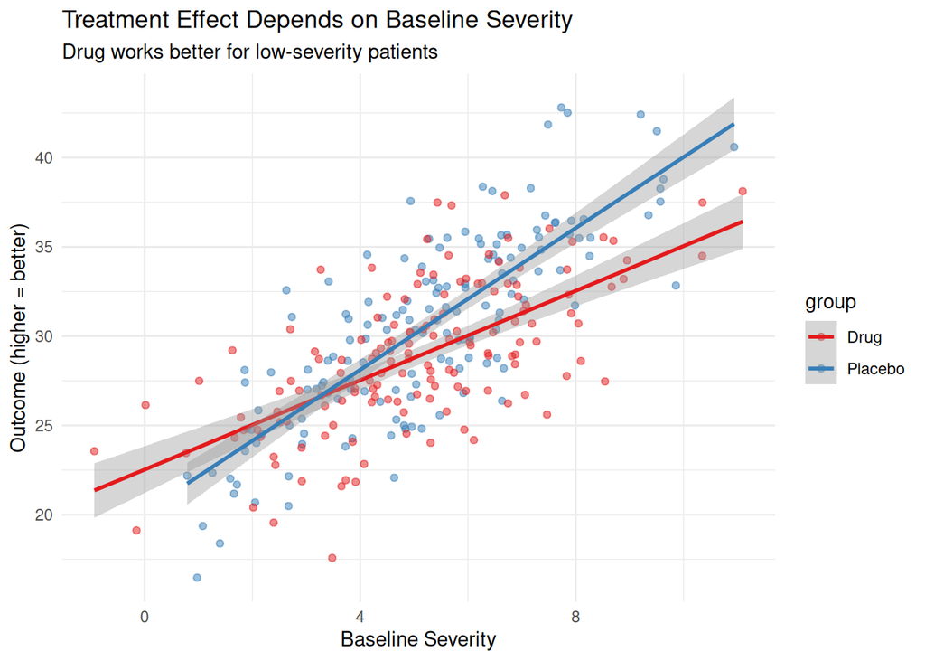

```r
set.seed(667)

# Simulate: continuous moderator x binary treatment
n <- 300
sim_data <- tibble(
  id = 1:n,
  # Continuous moderator (e.g., baseline severity score)
  severity = rnorm(n, mean = 5, sd = 2),
  # Binary treatment
  group = factor(rep(c("Placebo", "Drug"), each = n/2)),
  # Outcome with interaction:
  # - Drug has positive effect at low severity
  # - Drug effect diminishes (or reverses) at high severity
  Y = 20 +
      3 * (group == "Drug") +           # "main effect" at severity = 0
      2 * severity +                     # severity effect in placebo
      -0.8 * (group == "Drug") * severity +  # interaction
      rnorm(n, sd = 3)
)

# Visualize the interaction
ggplot(sim_data, aes(x = severity, y = Y, color = group)) +
  geom_point(alpha = 0.5) +
  geom_smooth(method = "lm", se = TRUE) +
  labs(
    title = "Treatment Effect Depends on Baseline Severity",
    subtitle = "Drug works better for low-severity patients",
    x = "Baseline Severity",
    y = "Outcome (higher = better)"
  ) +
  theme_minimal() +
  scale_color_brewer(palette = "Set1")
```

### Fit the Model and Examine “Main Effects”

```r
# Fit with uncentered severity
fit_uncentered <- lm(Y ~ group * severity, data = sim_data)
summary(fit_uncentered)
```

```
Call:
lm(formula = Y ~ group * severity, data = sim_data)

Residuals:
   Min     1Q Median     3Q    Max
-9.303 -2.062 -0.011  1.833  8.155

Coefficients:
                      Estimate Std. Error t value Pr(>|t|)
(Intercept)            22.5251     0.6710  33.571  < 2e-16 ***
groupPlacebo           -2.3523     0.9530  -2.468   0.0141 *
severity                1.2520     0.1224  10.230  < 2e-16 ***
groupPlacebo:severity   0.7336     0.1717   4.273 2.61e-05 ***
---
Signif. codes:  0 '***' 0.001 '**' 0.01 '*' 0.05 '.' 0.1 ' ' 1

Residual standard error: 3.124 on 296 degrees of freedom
Multiple R-squared:  0.5729,    Adjusted R-squared:  0.5686
F-statistic: 132.4 on 3 and 296 DF,  p-value: < 2.2e-16
```

```r
# What does severity = 0 mean?
summary(sim_data$severity)
```

```
   Min. 1st Qu.  Median    Mean 3rd Qu.    Max.
-0.9314  3.7303  5.1949  5.1383  6.5676 11.0973
```

```r
cat("\nProportion with severity < 0:", mean(sim_data$severity < 0))
```

```
Proportion with severity < 0: 0.006666667
```

### The Solution: Center at a Meaningful Value

```r
# Center at the mean
sim_data$severity_c <- sim_data$severity - mean(sim_data$severity)

fit_centered <- lm(Y ~ group * severity_c, data = sim_data)
summary(fit_centered)
```

```
Call:
lm(formula = Y ~ group * severity_c, data = sim_data)

Residuals:
   Min     1Q Median     3Q    Max
-9.303 -2.062 -0.011  1.833  8.155

Coefficients:
                        Estimate Std. Error t value Pr(>|t|)
(Intercept)              28.9581     0.2552 113.478  < 2e-16 ***
groupPlacebo              1.4171     0.3609   3.927 0.000107 ***
severity_c                1.2520     0.1224  10.230  < 2e-16 ***
groupPlacebo:severity_c   0.7336     0.1717   4.273 2.61e-05 ***
---
Signif. codes:  0 '***' 0.001 '**' 0.01 '*' 0.05 '.' 0.1 ' ' 1

Residual standard error: 3.124 on 296 degrees of freedom
Multiple R-squared:  0.5729,    Adjusted R-squared:  0.5686
F-statistic: 132.4 on 3 and 296 DF,  p-value: < 2.2e-16
```

### Use emmeans for Proper Analysis

```r
# Estimate treatment effect at specific severity values
severity_values <- quantile(sim_data$severity, probs = c(0.25, 0.5, 0.75))

# Simple effects: treatment effect at each severity level
emm <- emmeans(fit_uncentered, ~ group | severity,
               at = list(severity = severity_values))
emm
```

```
severity = 3.73:
 group   emmean    SE  df lower.CL upper.CL
 Drug      27.2 0.303 296     26.6     27.8
 Placebo   27.6 0.311 296     27.0     28.2

severity = 5.19:
 group   emmean    SE  df lower.CL upper.CL
 Drug      29.0 0.256 296     28.5     29.5
 Placebo   30.5 0.255 296     30.0     31.0

severity = 6.57:
 group   emmean    SE  df lower.CL upper.CL
 Drug      30.7 0.314 296     30.1     31.4
 Placebo   33.2 0.303 296     32.6     33.8

Confidence level used: 0.95
```

```r
# Contrasts: Drug vs Placebo at each severity level
contrast(emm, method = "pairwise")
```

```
severity = 3.73:
 contrast       estimate    SE  df t.ratio p.value
 Drug - Placebo   -0.384 0.434 296  -0.885  0.3770

severity = 5.19:
 contrast       estimate    SE  df t.ratio p.value
 Drug - Placebo   -1.459 0.361 296  -4.040 <0.0001

severity = 6.57:
 contrast       estimate    SE  df t.ratio p.value
 Drug - Placebo   -2.466 0.437 296  -5.648 <0.0001
```

## 4. The Right Way: Simple Effects Analysis

Instead of testing meaningless “main effects,” use **simple effects**: test the effect of one factor at specific, meaningful levels of the other factor.

### Using emmeans

```r
# Define meaningful values of the moderator
meaningful_values <- list(
  severity = c(
    "Low (25th %ile)" = quantile(sim_data$severity, 0.25),
    "Medium (50th %ile)" = quantile(sim_data$severity, 0.50),
    "High (75th %ile)" = quantile(sim_data$severity, 0.75)
  )
)

# Get estimated marginal means
emm_simple <- emmeans(fit_uncentered, ~ group | severity,
                      at = list(severity = unname(meaningful_values$severity)))

# Simple effects with confidence intervals
simple_effects <- contrast(emm_simple, method = "pairwise")
summary(simple_effects, infer = TRUE)
```

```
severity = 3.73:
 contrast       estimate    SE  df lower.CL upper.CL t.ratio p.value
 Drug - Placebo   -0.384 0.434 296    -1.24    0.470  -0.885  0.3770

severity = 5.19:
 contrast       estimate    SE  df lower.CL upper.CL t.ratio p.value
 Drug - Placebo   -1.459 0.361 296    -2.17   -0.748  -4.040 <0.0001

severity = 6.57:
 contrast       estimate    SE  df lower.CL upper.CL t.ratio p.value
 Drug - Placebo   -2.466 0.437 296    -3.32   -1.607  -5.648 <0.0001

Confidence level used: 0.95
```

### Visualization with emmip

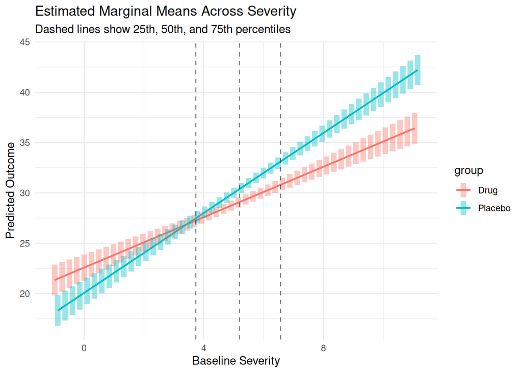

```r
# Create a nice visualization
emmip(fit_uncentered, group ~ severity,
      at = list(severity = seq(min(sim_data$severity),
                               max(sim_data$severity),
                               length.out = 50)),
      CIs = TRUE) +
  geom_vline(xintercept = meaningful_values$severity,
             linetype = "dashed", alpha = 0.5) +
  labs(
    title = "Estimated Marginal Means Across Severity",
    subtitle = "Dashed lines show 25th, 50th, and 75th percentiles",
    x = "Baseline Severity",
    y = "Predicted Outcome"
  ) +
  theme_minimal()
```

```r
# At what severity level does the treatment effect become non-significant?
# Use emtrends to examine the slope

# Trend of treatment effect across severity
emtrends(fit_uncentered, ~ group, var = "severity")
```

```
 group   severity.trend    SE  df lower.CL upper.CL
 Drug              1.25 0.122 296     1.01     1.49
 Placebo           1.99 0.120 296     1.75     2.22

Confidence level used: 0.95
```

```r
# The interaction coefficient tells us the rate of change
coef(fit_uncentered)["groupDrug:severity"]
```

```
<NA>
  NA
```

## 5. Two Factors Example: Categorical x Categorical

The same principles apply when both factors are categorical.

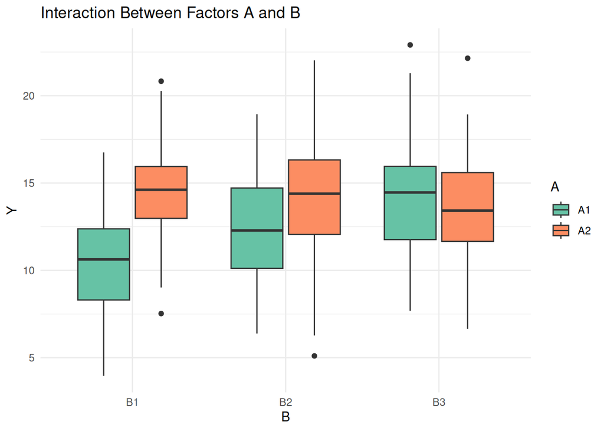

```r
set.seed(667)

# Simulate a 2x3 design
n_per_cell <- 50
two_factor <- expand_grid(
  A = factor(c("A1", "A2")),
  B = factor(c("B1", "B2", "B3")),
  rep = 1:n_per_cell
) |>
  mutate(
    # True means with interaction
    mu = case_when(
      A == "A1" & B == "B1" ~ 10,
      A == "A1" & B == "B2" ~ 12,
      A == "A1" & B == "B3" ~ 14,
      A == "A2" & B == "B1" ~ 15,  # Big effect of A at B1
      A == "A2" & B == "B2" ~ 14,  # Small effect at B2
      A == "A2" & B == "B3" ~ 13   # Negative effect at B3!
    ),
    Y = mu + rnorm(n(), sd = 3)
  )

# Visualize
ggplot(two_factor, aes(x = B, y = Y, fill = A)) +
  geom_boxplot() +
  labs(title = "Interaction Between Factors A and B") +
  theme_minimal() +
  scale_fill_brewer(palette = "Set2")
```

### The “Main Effect” Trap with Two Factors

```r
# Fit the interaction model
fit_two <- lm(Y ~ A * B, data = two_factor)
summary(fit_two)
```

```
Call:
lm(formula = Y ~ A * B, data = two_factor)

Residuals:
    Min      1Q  Median      3Q     Max
-9.0916 -2.0992  0.0062  2.0034  8.8657

Coefficients:
            Estimate Std. Error t value Pr(>|t|)
(Intercept)  10.3741     0.4481  23.149  < 2e-16 ***
AA2           4.2262     0.6338   6.668 1.28e-10 ***
BB2           2.1348     0.6338   3.368 0.000857 ***
BB3           3.6680     0.6338   5.788 1.83e-08 ***
AA2:BB2      -2.5405     0.8963  -2.834 0.004908 **
AA2:BB3      -4.7437     0.8963  -5.293 2.36e-07 ***
---
Signif. codes:  0 '***' 0.001 '**' 0.01 '*' 0.05 '.' 0.1 ' ' 1

Residual standard error: 3.169 on 294 degrees of freedom
Multiple R-squared:  0.1716,    Adjusted R-squared:  0.1575
F-statistic: 12.18 on 5 and 294 DF,  p-value: 9.775e-11
```

**What does `AA2` coefficient mean?**

- It’s the effect of A2 vs A1 **when B = B1** (the reference level)
- It does NOT represent the “overall” effect of A

### The Right Analysis: Simple Effects

```r
# Estimated marginal means
emm_two <- emmeans(fit_two, ~ A | B)
emm_two
```

```
B = B1:
 A  emmean    SE  df lower.CL upper.CL
 A1   10.4 0.448 294     9.49     11.3
 A2   14.6 0.448 294    13.72     15.5

B = B2:
 A  emmean    SE  df lower.CL upper.CL
 A1   12.5 0.448 294    11.63     13.4
 A2   14.2 0.448 294    13.31     15.1

B = B3:
 A  emmean    SE  df lower.CL upper.CL
 A1   14.0 0.448 294    13.16     14.9
 A2   13.5 0.448 294    12.64     14.4

Confidence level used: 0.95
```

```r
# Simple effect of A at each level of B
contrast(emm_two, method = "pairwise")
```

```
B = B1:
 contrast estimate    SE  df t.ratio p.value
 A1 - A2    -4.226 0.634 294  -6.668 <0.0001

B = B2:
 contrast estimate    SE  df t.ratio p.value
 A1 - A2    -1.686 0.634 294  -2.660  0.0083

B = B3:
 contrast estimate    SE  df t.ratio p.value
 A1 - A2     0.517 0.634 294   0.817  0.4149
```

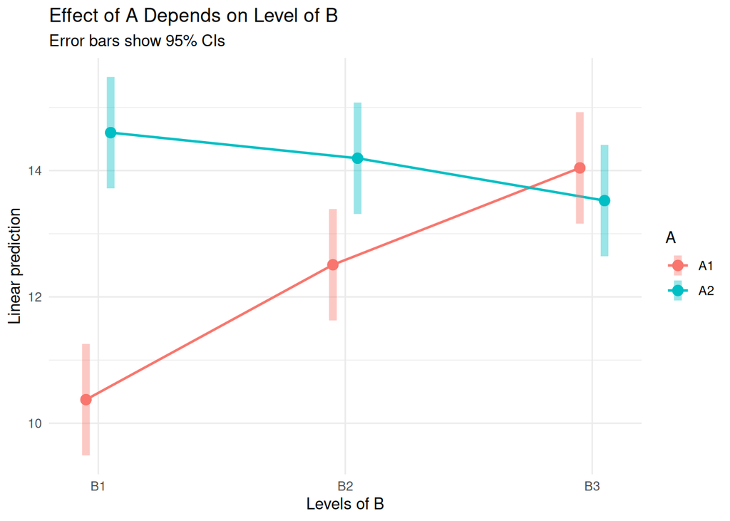

```r
# Interaction plot
emmip(fit_two, A ~ B, CIs = TRUE) +
  labs(
    title = "Effect of A Depends on Level of B",
    subtitle = "Error bars show 95% CIs"
  ) +
  theme_minimal()
```

### Average Effect Across Levels

If you want an “overall” effect of A (averaging across B levels):

```r
# Marginal means for A (averaging over B)
emmeans(fit_two, ~ A) |>
  contrast(method = "pairwise")
```

```
 contrast estimate    SE  df t.ratio p.value
 A1 - A2      -1.8 0.366 294  -4.914 <0.0001

Results are averaged over the levels of: B
```

## 6. Connection to Type III ANOVA

Type III sums of squares test “main effects” at the reference levels of other factors—which means they suffer from the same centering problem!

### Type III Tests Change with Centering

```r
# Using our continuous x binary example
# Type III ANOVA with uncentered severity
cat("Type III ANOVA with UNCENTERED severity:\n")
```

```
Type III ANOVA with UNCENTERED severity:
```

```r
Anova(fit_uncentered, type = "III")
```

```
Anova Table (Type III tests)

Response: Y
                Sum Sq  Df   F value    Pr(>F)
(Intercept)    10997.4   1 1127.0259 < 2.2e-16 ***
group             59.5   1    6.0929   0.01414 *
severity        1021.2   1  104.6557 < 2.2e-16 ***
group:severity   178.1   1   18.2567 2.605e-05 ***
Residuals       2888.3 296
---
Signif. codes:  0 '***' 0.001 '**' 0.01 '*' 0.05 '.' 0.1 ' ' 1
```

```r
cat("\n\nType III ANOVA with CENTERED severity:\n")
```

```
Type III ANOVA with CENTERED severity:
```

```r
Anova(fit_centered, type = "III")
```

```
Anova Table (Type III tests)

Response: Y
                 Sum Sq  Df   F value    Pr(>F)
(Intercept)      125655   1 12877.260 < 2.2e-16 ***
group               150   1    15.419 0.0001072 ***
severity_c         1021   1   104.656 < 2.2e-16 ***
group:severity_c    178   1    18.257 2.605e-05 ***
Residuals          2888 296
---
Signif. codes:  0 '***' 0.001 '**' 0.01 '*' 0.05 '.' 0.1 ' ' 1
```

### What Type III Actually Tests

| Effect | Type III tests… |
| --- | --- |
| Group | Group effect when severity = 0 (or mean if centered) |
| Severity | Severity effect in the reference group |
| Interaction | Whether slopes differ between groups |

**The interaction test is invariant to centering**, but the main effect tests are not!

### Recommendation

For models with interactions:

1. **Do** use Type III for the interaction test
2. **Don’t** interpret the Type III main effect tests
3. **Do** use emmeans for simple effects at meaningful values

```r
# The interaction test is what matters
Anova(fit_uncentered, type = "III")["group:severity", ]
```

```
Anova Table (Type III tests)

Response: Y
               Sum Sq Df F value    Pr(>F)
group:severity 178.15  1  18.257 2.605e-05 ***
---
Signif. codes:  0 '***' 0.001 '**' 0.01 '*' 0.05 '.' 0.1 ' ' 1
```

```r
# Follow up with simple effects
emmeans(fit_uncentered, pairwise ~ group | severity,
        at = list(severity = c(3, 5, 7)))
```

```
$emmeans
severity = 3:
 group   emmean    SE  df lower.CL upper.CL
 Drug      26.3 0.360 296     25.6     27.0
 Placebo   26.1 0.368 296     25.4     26.9

severity = 5:
 group   emmean    SE  df lower.CL upper.CL
 Drug      28.8 0.255 296     28.3     29.3
 Placebo   30.1 0.256 296     29.6     30.6

severity = 7:
 group   emmean    SE  df lower.CL upper.CL
 Drug      31.3 0.348 296     30.6     32.0
 Placebo   34.1 0.334 296     33.4     34.7

Confidence level used: 0.95

$contrasts
severity = 3:
 contrast       estimate    SE  df t.ratio p.value
 Drug - Placebo    0.152 0.515 296   0.294  0.7687

severity = 5:
 contrast       estimate    SE  df t.ratio p.value
 Drug - Placebo   -1.316 0.362 296  -3.638  0.0003

severity = 7:
 contrast       estimate    SE  df t.ratio p.value
 Drug - Placebo   -2.783 0.482 296  -5.771 <0.0001
```

## 7. Best Practices Checklist

When you have an interaction in your model, follow these steps:

### Step 1: STOP

**Do not interpret main effect p-values from summary() or Anova().**

These test conditional effects at reference/zero values that may be meaningless.

### Step 2: VISUALIZE

Plot the interaction to understand the pattern.

```r
# For continuous x categorical
ggplot(data, aes(x = continuous_var, y = outcome, color = group)) +
  geom_point() +
  geom_smooth(method = "lm")

# Or use emmip
emmip(fit, group ~ continuous_var, CIs = TRUE)
```

### Step 3: PROBE

Test simple effects at meaningful values of the moderator.

```r
# Define meaningful values
meaningful_X <- c(low = 2, medium = 5, high = 8)

# Get simple effects
emmeans(fit, pairwise ~ group | X, at = list(X = meaningful_X))
```

### Step 4: SUMMARIZE

If you need an “overall” effect, compute the average marginal effect.

```r
# Average effect across the distribution of the moderator
emmeans(fit, pairwise ~ group)  # Averages over other variables
```

### Quick Reference Table

| What you want | What to do |
| --- | --- |
| Test if interaction exists | Type III ANOVA or summary() interaction term |
| Effect of A at specific B | `emmeans(fit, ~ A \| B, at = list(B = value))` |
| Effect of A averaged over B | `emmeans(fit, ~ A)` with pairwise contrasts |
| Visualize the interaction | `emmip()` or ggplot with `geom_smooth()` |
| Find where effect becomes significant | Johnson-Neyman technique |

## 8. Note on GLMs

The same principles apply to generalized linear models (logistic, Poisson, etc.), with an additional consideration: the **scale of interpretation**.

### Example: Logistic Regression

```r
set.seed(667)

# Simulate binary outcome with interaction
n <- 500
glm_data <- tibble(
  age = rnorm(n, mean = 50, sd = 10),
  treatment = factor(rep(c("Control", "Active"), each = n/2)),
  # Log-odds with interaction
  log_odds = -2 +
             0.5 * (treatment == "Active") +
             0.03 * age +
             -0.02 * (treatment == "Active") * age,
  prob = plogis(log_odds),
  Y = rbinom(n, 1, prob)
)

# Fit logistic regression
fit_glm <- glm(Y ~ treatment * age, data = glm_data, family = binomial)
summary(fit_glm)
```

```
Call:
glm(formula = Y ~ treatment * age, family = binomial, data = glm_data)

Coefficients:
                      Estimate Std. Error z value Pr(>|z|)
(Intercept)          -1.592264   0.752155  -2.117   0.0343 *
treatmentControl     -1.065036   1.021475  -1.043   0.2971
age                   0.008632   0.014414   0.599   0.5493
treatmentControl:age  0.032811   0.019502   1.682   0.0925 .
---
Signif. codes:  0 '***' 0.001 '**' 0.01 '*' 0.05 '.' 0.1 ' ' 1

(Dispersion parameter for binomial family taken to be 1)

    Null deviance: 614.22  on 499  degrees of freedom
Residual deviance: 593.54  on 496  degrees of freedom
AIC: 601.54

Number of Fisher Scoring iterations: 4
```